# Lead Data Scientist, Curves- Test Output

Olushina Olawale Awe, PhD.

2023-04-08

```r
### Install all necessary packages
library(gamlss.ggplots)
library(ggplot2)
library(gamlss)
library(gamlss.add)
library(gamlss.dist)
library(corrplot)
library(cowplot)
library(Hmisc)
library(dplyr)
library(forecast)
library(tseries)
library(psych)
library(Boruta)
library(caret)
library(caretEnsemble)
```

### 0. Preamble

In this test excercise, I am going to demonstrate how to approach a data science problem, supporting my explanation with the oil price data available in the gamlss package, while performing a one-day ahead forecast for oil prices. I will adopt the following outline which also serves as the steps involved:

- 1. Problem Statement and Objective
- 2. Data Extraction and Description
- 3. Data Exploration and Pre-processing
- 4. Model Building
- 5. Model Evaluation and Validation
- 6. Forecasting
- 7. Interpretation and Conclusion

Let us consider these steps one after the other as follows:

### 1. Problem Statement and Objective

The objective of this excercise is to conduct a probalistic forecast of oil price using gamlss model selection technique to discover the most important variables that affects the price of oil. Based on real global events, non-seasonality of oil price, among other issues, there is currently no known best method for predicting Oil prices in literature, therefore, oil companies and oil service companies will have to adapt to recent world activities that impact oil production. There are several variables that can indirectly impact oil prices. The main goal here is to use some financially traded vagaries to discover what might affect the daily dynamics of the price of oil by using GAMLSS model selection techniques to discover what affects the price of oil and obtain a one day ahead forecast. Due to the the “No free lunch theorem” and the “Bias-Variance Trade off” in machine learning, it is difficult to select and adopt a single model for forecasting but we fit basic models in this exercise mainly for illustrative purposes.

### 2. Data Extraction and Description: The Oil Price Data

The oil data is available in the GAMLSS package in R. We can load the data with the following code:

```r
oil <- gamlss.data::oil
#oil
```

Check the size of the data

```r
dim(oil) # The data has 25 variables and 1000 observations
```

```
## [1] 1000   25
```

Let us consider the names of the variables and see the data description. Upon obtaining information about the data and data dictionary, we notice that all the variables are numeric and seem to have similar scales.

```r
names(oil)
```

```
##  [1] "OILPRICE"   "CL2_log"    "CL3_log"    "CL4_log"    "CL5_log"
##  [6] "CL6_log"    "CL7_log"    "CL8_log"    "CL9_log"    "CL10_log"
## [11] "CL11_log"   "CL12_log"   "CL13_log"   "CL14_log"   "CL15_log"
## [16] "BDIY_log"   "SPX_log"    "DX1_log"    "GC1_log"    "HO1_log"
## [21] "USCI_log"   "GNR_log"    "SHCOMP_log" "FTSE_log"   "respLAG"
```

#### Data description

```r
#help(oil)
str(oil)
```

```
## 'data.frame':    1000 obs. of  25 variables:
##  $ OILPRICE  : num  4.64 4.63 4.63 4.65 4.63 ...
##  $ CL2_log   : num  4.64 4.65 4.64 4.64 4.65 ...
##  $ CL3_log   : num  4.64 4.65 4.64 4.64 4.65 ...
##  $ CL4_log   : num  4.64 4.65 4.65 4.65 4.66 ...
##  $ CL5_log   : num  4.65 4.66 4.65 4.65 4.66 ...
##  $ CL6_log   : num  4.65 4.66 4.65 4.65 4.66 ...
##  $ CL7_log   : num  4.65 4.66 4.65 4.65 4.66 ...
##  $ CL8_log   : num  4.65 4.66 4.65 4.65 4.66 ...
##  $ CL9_log   : num  4.65 4.66 4.66 4.65 4.66 ...
##  $ CL10_log  : num  4.65 4.66 4.66 4.65 4.66 ...
##  $ CL11_log  : num  4.65 4.66 4.65 4.65 4.66 ...
##  $ CL12_log  : num  4.65 4.66 4.65 4.65 4.66 ...
##  $ CL13_log  : num  4.65 4.65 4.65 4.64 4.65 ...
##  $ CL14_log  : num  4.64 4.65 4.65 4.64 4.65 ...
##  $ CL15_log  : num  4.64 4.65 4.64 4.64 4.65 ...
##  $ BDIY_log  : num  6.85 6.85 6.88 6.88 6.9 ...
##  $ SPX_log   : num  7.22 7.24 7.22 7.22 7.24 ...
##  $ DX1_log   : num  4.39 4.38 4.39 4.38 4.38 ...
##  $ GC1_log   : num  7.41 7.42 7.42 7.41 7.4 ...
##  $ HO1_log   : num  1.14 1.15 1.16 1.14 1.14 ...
##  $ USCI_log  : num  4.11 4.12 4.12 4.1 4.11 ...
##  $ GNR_log   : num  3.92 3.94 3.92 3.93 3.94 ...
##  $ SHCOMP_log: num  7.74 7.76 7.77 7.77 7.76 ...
##  $ FTSE_log  : num  8.64 8.65 8.64 8.64 8.66 ...
##  $ respLAG   : num  4.63 4.64 4.63 4.63 4.65 ...
```

The dataset contains the daily prices of front month WTI (West Texas Intermediate) oil price traded by NYMEX (New York Mercantile Exchange). The front month WTI oil price is a futures contract with the shortest duration that could be purchased in the NYMEX market. It can be seen that the oil dataset in the GAMLSS package contains the following numeric variables:

- OILPRICE: The log price of the front month WTI oil contract traded by NYMEX - in financial terms, this is the CL1. This is the response/target variable.
- CL(2,..,15)_LOG: Numeric vectors which are the log prices of the 2 to 15 months ahead WTI oil contracts traded by NYMEX. For example, for the trading day of 2nd June 2016, the CL2 is the WTI oil contract for delivery in August 2016.
- BDIY_LOG: The Baltic Dry Index, which is an assessment of the price of moving the major raw materials by sea.
- SPX_LOG: The S&P 500 index.
- DX1_LOG: The US Dollar Index.
- GC1_LOG: The log price of the front month gold price contract traded by NYMEX.
- HO1_LOG: The log price of the front month heating oil contract traded by NYMEX.
- USCI_LOG: The United States Commodity Index.
- GNR_LOG: The S&P Global Natural Resources Index.
- SHCOMP_LOG: The Shanghai Stock Exchange Composite Index.
- FTSE_LOG: The FTSE 100 Index.
- RESPLAG: The lag 1 of OILPRICE - lagged version of the response variable.

### 3. Data Exploration and Preprocessing.

Check if there are null and missing values in the data:

```r
is.null(oil)
```

```
## [1] FALSE
```

```r
sum(is.na(oil)) # The data contains no zero and missing values.
```

```
## [1] 0
```

```r
attach(oil)
```

Plot OILPRICE with an assumed date to see how the price changes over time. Since there is no specific date attached to the data, we assume a starting date for the data.

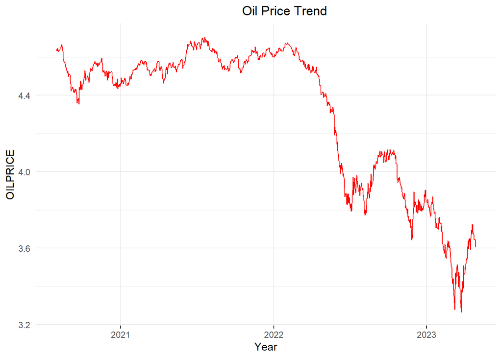

```r
oildata <- oil

# added an arbitrary date
oildata$Date <- as.Date(c(0:999), origin="2020-08-01")
# The time series plot of the data shows that the data is not seasonal
# select required columns
data_new <- oildata[, c("OILPRICE", "Date")]
ggplot(data_new) +
  aes(x = Date, y = OILPRICE) +
  geom_line(color = 'red') + theme_cowplot() +
  labs(title = 'Oil Price Trend', x = 'Year') +
  theme_minimal() +
  theme(
    plot.title = element_text(hjust = 0.55),
          panel.grid.minor.x = element_blank(),
          axis.ticks.x = element_line(color = "black")
  )
```

#### Descriptive Statistics and Exploratory Data Analysis

I explore the data as follows to further confirm that there are no missing values or outliers in the data.

```r
summary(oildata[,-26])
```

```
##     OILPRICE        CL2_log         CL3_log         CL4_log
##  Min.   :3.266   Min.   :3.345   Min.   :3.391   Min.   :3.428
##  1st Qu.:3.966   1st Qu.:3.982   1st Qu.:4.001   1st Qu.:4.017
##  Median :4.517   Median :4.519   Median :4.519   Median :4.518
##  Mean   :4.309   Mean   :4.317   Mean   :4.322   Mean   :4.326
##  3rd Qu.:4.580   3rd Qu.:4.581   3rd Qu.:4.581   3rd Qu.:4.579
##  Max.   :4.705   Max.   :4.696   Max.   :4.682   Max.   :4.672
##     CL5_log         CL6_log         CL7_log         CL8_log
##  Min.   :3.482   Min.   :3.501   Min.   :3.516   Min.   :3.529
##  1st Qu.:4.032   1st Qu.:4.048   1st Qu.:4.058   1st Qu.:4.068
##  Median :4.519   Median :4.518   Median :4.517   Median :4.514
##  Mean   :4.329   Mean   :4.331   Mean   :4.332   Mean   :4.333
##  3rd Qu.:4.575   3rd Qu.:4.570   3rd Qu.:4.563   3rd Qu.:4.556
##  Max.   :4.672   Max.   :4.673   Max.   :4.673   Max.   :4.673
##     CL9_log         CL10_log        CL11_log        CL12_log
##  Min.   :3.542   Min.   :3.555   Min.   :3.566   Min.   :3.576
##  1st Qu.:4.075   1st Qu.:4.082   1st Qu.:4.090   1st Qu.:4.097
##  Median :4.512   Median :4.509   Median :4.506   Median :4.503
##  Mean   :4.333   Mean   :4.337   Mean   :4.333   Mean   :4.332
##  3rd Qu.:4.550   3rd Qu.:4.546   3rd Qu.:4.542   3rd Qu.:4.537
##  Max.   :4.672   Max.   :4.670   Max.   :4.667   Max.   :4.663
##     CL13_log        CL14_log        CL15_log        BDIY_log
##  Min.   :3.585   Min.   :3.594   Min.   :3.603   Min.   :5.670
##  1st Qu.:4.103   1st Qu.:4.110   1st Qu.:4.117   1st Qu.:6.596
##  Median :4.500   Median :4.497   Median :4.493   Median :6.806
##  Mean   :4.332   Mean   :4.331   Mean   :4.331   Mean   :6.787
##  3rd Qu.:4.532   3rd Qu.:4.527   3rd Qu.:4.522   3rd Qu.:7.011
##  Max.   :4.658   Max.   :4.654   Max.   :4.649   Max.   :7.757
##     SPX_log         DX1_log         GC1_log         HO1_log
##  Min.   :7.153   Min.   :4.369   Min.   :6.956   Min.   :-0.1442
##  1st Qu.:7.354   1st Qu.:4.391   1st Qu.:7.089   1st Qu.: 0.6220
##  Median :7.531   Median :4.417   Median :7.159   Median : 1.0547
##  Mean   :7.481   Mean   :4.459   Mean   :7.192   Mean   : 0.8600
##  3rd Qu.:7.611   3rd Qu.:4.557   3rd Qu.:7.345   3rd Qu.: 1.1013
##  Max.   :7.664   Max.   :4.613   Max.   :7.491   Max.   : 1.1877
##     USCI_log        GNR_log        SHCOMP_log       FTSE_log
##  Min.   :3.650   Min.   :3.317   Min.   :7.576   Min.   :8.568
##  1st Qu.:3.838   1st Qu.:3.787   1st Qu.:7.652   1st Qu.:8.716
##  Median :4.021   Median :3.868   Median :7.734   Median :8.778
##  Mean   :3.962   Mean   :3.818   Mean   :7.840   Mean   :8.760
##  3rd Qu.:4.070   3rd Qu.:3.920   3rd Qu.:8.032   3rd Qu.:8.813
##  Max.   :4.148   Max.   :3.985   Max.   :8.550   Max.   :8.868
##     respLAG
##  Min.   :3.266
##  1st Qu.:3.966
##  Median :4.517
##  Mean   :4.310
##  3rd Qu.:4.580
##  Max.   :4.705
```

or better still, we can use describe function in the psych package to get a better glimpse of the descriptive statistics of the data. It can be seen that the data has been well transformed as most of the mean values revolves around the same values for each variable.

```r
describe(oildata[,-26])
```

```
##            vars    n mean   sd median trimmed  mad   min  max range  skew
## OILPRICE      1 1000 4.31 0.37   4.52    4.36 0.17  3.27 4.71  1.44 -0.93
## CL2_log       2 1000 4.32 0.36   4.52    4.36 0.16  3.34 4.70  1.35 -0.91
## CL3_log       3 1000 4.32 0.35   4.52    4.37 0.15  3.39 4.68  1.29 -0.91
## CL4_log       4 1000 4.33 0.34   4.52    4.37 0.14  3.43 4.67  1.24 -0.91
## CL5_log       5 1000 4.33 0.33   4.52    4.37 0.12  3.48 4.67  1.19 -0.91
## CL6_log       6 1000 4.33 0.32   4.52    4.37 0.11  3.50 4.67  1.17 -0.92
## CL7_log       7 1000 4.33 0.31   4.52    4.37 0.10  3.52 4.67  1.16 -0.92
## CL8_log       8 1000 4.33 0.31   4.51    4.37 0.10  3.53 4.67  1.14 -0.93
## CL9_log       9 1000 4.33 0.30   4.51    4.37 0.10  3.54 4.67  1.13 -0.94
## CL10_log     10 1000 4.34 0.29   4.51    4.37 0.09  3.56 4.67  1.11 -0.90
## CL11_log     11 1000 4.33 0.29   4.51    4.37 0.09  3.57 4.67  1.10 -0.95
## CL12_log     12 1000 4.33 0.28   4.50    4.37 0.08  3.58 4.66  1.09 -0.95
## CL13_log     13 1000 4.33 0.28   4.50    4.37 0.08  3.59 4.66  1.07 -0.96
## CL14_log     14 1000 4.33 0.27   4.50    4.37 0.07  3.59 4.65  1.06 -0.96
## CL15_log     15 1000 4.33 0.27   4.49    4.37 0.07  3.60 4.65  1.05 -0.97
## BDIY_log     16 1000 6.79 0.40   6.81    6.79 0.31  5.67 7.76  2.09 -0.25
## SPX_log      17 1000 7.48 0.15   7.53    7.49 0.15  7.15 7.66  0.51 -0.58
## DX1_log      18 1000 4.46 0.08   4.42    4.45 0.05  4.37 4.61  0.24  0.65
## GC1_log      19 1000 7.19 0.14   7.16    7.18 0.12  6.96 7.49  0.53  0.56
## HO1_log      20 1000 0.86 0.33   1.05    0.91 0.11 -0.14 1.19  1.33 -1.12
## USCI_log     21 1000 3.96 0.14   4.02    3.98 0.10  3.65 4.15  0.50 -0.81
## GNR_log      22 1000 3.82 0.15   3.87    3.84 0.09  3.32 3.98  0.67 -1.42
## SHCOMP_log   23 1000 7.84 0.24   7.73    7.81 0.15  7.58 8.55  0.97  1.04
## FTSE_log     24 1000 8.76 0.07   8.78    8.77 0.06  8.57 8.87  0.30 -0.73
## respLAG      25 1000 4.31 0.37   4.52    4.36 0.17  3.27 4.71  1.44 -0.94
##            kurtosis   se
## OILPRICE      -0.54 0.01
## CL2_log       -0.61 0.01
## CL3_log       -0.65 0.01
## CL4_log       -0.67 0.01
## CL5_log       -0.67 0.01
## CL6_log       -0.66 0.01
## CL7_log       -0.65 0.01
## CL8_log       -0.63 0.01
## CL9_log       -0.61 0.01
## CL10_log      -0.71 0.01
## CL11_log      -0.58 0.01
## CL12_log      -0.57 0.01
## CL13_log      -0.55 0.01
## CL14_log      -0.53 0.01
## CL15_log      -0.51 0.01
## BDIY_log       0.55 0.01
## SPX_log       -1.05 0.00
## DX1_log       -1.32 0.00
## GC1_log       -0.86 0.00
## HO1_log        0.00 0.01
## USCI_log      -0.79 0.00
## GNR_log        1.08 0.00
## SHCOMP_log    -0.10 0.01
## FTSE_log      -0.36 0.00
## respLAG       -0.53 0.01
```

#### Data Reduction

I reduce the data by creating a subset of the data,which implies removing the last day’s negotiations.

```r
oildata_s = oildata[,-2:-15]# Remove the last day's negotiations
#oildata_s
oildata_s= oildata_s[,-12]
names(oildata_s)
```

```
##  [1] "OILPRICE"   "BDIY_log"   "SPX_log"    "DX1_log"    "GC1_log"
##  [6] "HO1_log"    "USCI_log"   "GNR_log"    "SHCOMP_log" "FTSE_log"
## [11] "respLAG"
```

```r
head(oildata_s)
```

```
##   OILPRICE BDIY_log  SPX_log  DX1_log  GC1_log  HO1_log USCI_log  GNR_log
## 1 4.640923 6.850126 7.221624 4.386554 7.413367 1.136197 4.108412 3.917806
## 2 4.633077 6.850126 7.235309 4.379762 7.419680 1.152564 4.120986 3.942552
## 3 4.634049 6.879356 7.222756 4.387449 7.418481 1.155182 4.115127 3.923952
## 4 4.646312 6.882437 7.222252 4.383675 7.410347 1.136743 4.103965 3.925531
## 5 4.631520 6.896694 7.237620 4.382364 7.399704 1.139946 4.107096 3.941970
## 6 4.627616 6.913737 7.233556 4.382951 7.404888 1.137256 4.097672 3.936325
##   SHCOMP_log FTSE_log  respLAG
## 1   7.744539 8.636699 4.631812
## 2   7.762536 8.650062 4.640923
## 3   7.766061 8.639729 4.633077
## 4   7.765158 8.642292 4.634049
## 5   7.755763 8.659907 4.646312
## 6   7.775213 8.656137 4.631520
```

```r
dim(oildata_s)
```

```
## [1] 1000   11
```

#### Variable Transformation

The variables in the dataset are already log transformed. Applying more transformations to these variables would bring about a complex interpretation of the data. More so, the gamlss model accepts various types of distributions for the independent variables. Prices are known to have asymmetric distributions, and they are well fitted in the GAMLSS. We can therefore proceed directly to model building.

#### Data Visualization

Let us examine the descriptive distribution of the variables. Further examine the visual relationship of each variable with the response variable- OILPRICE to obtain a clearer picture.

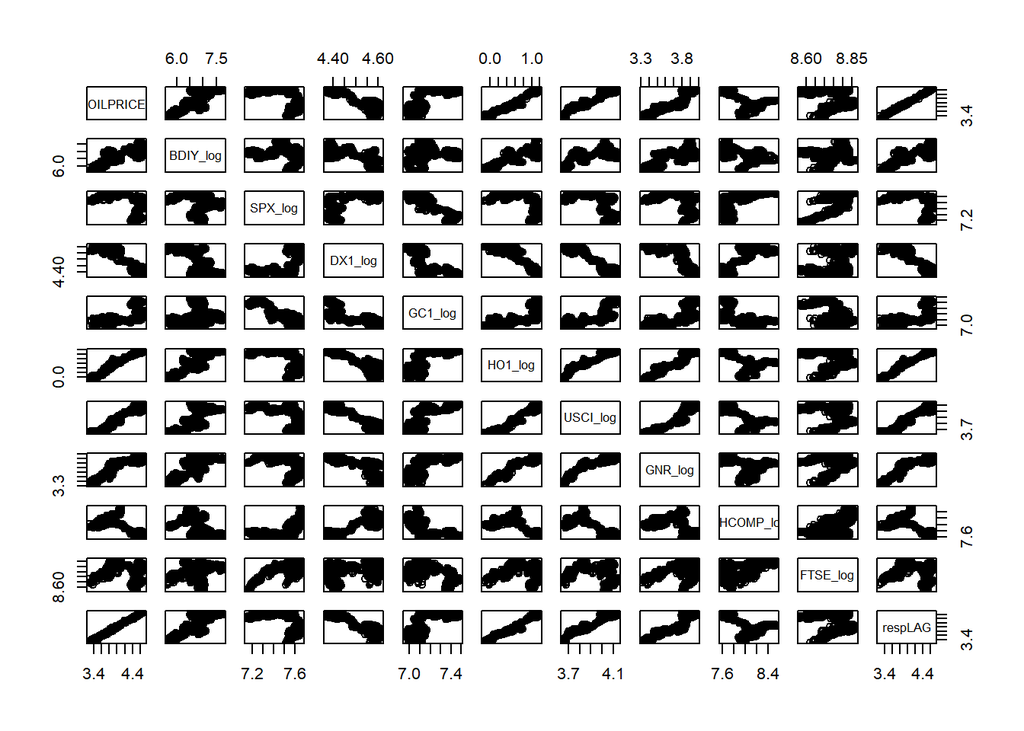

```r
pairs(oildata_s)
```

```r
plot1 <- ggplot(oildata_s, aes(SPX_log, OILPRICE)) +
  geom_point(color = 'red') + theme_cowplot(12)
plot2 <- ggplot(oildata_s, aes(DX1_log, OILPRICE)) +
  geom_point(color = 'blue') + theme_cowplot(12)
plot3 <- ggplot(oildata_s, aes(BDIY_log, OILPRICE)) +
  geom_point(color = 'black')+ theme_cowplot(12)
plot4 <- ggplot(oildata_s, aes(GC1_log, OILPRICE)) +
  geom_point(color = 'yellow')+theme_cowplot(12)
plot5 <- ggplot(oildata_s, aes(HO1_log, OILPRICE)) +
  geom_point(color = 'green')
plot6 <- ggplot(oildata_s, aes(FTSE_log, OILPRICE)) +
  geom_point(color = 'grey')
  plot7 <- ggplot(oildata_s, aes(USCI_log, OILPRICE)) +
  geom_point(color = 'pink')
plot8 <- ggplot(oildata_s, aes(GNR_log, OILPRICE)) +
  geom_point(color = 'violet')
plot9 <- ggplot(oildata_s, aes(SHCOMP_log, OILPRICE)) +
  geom_point(color = 'lightblue')
```

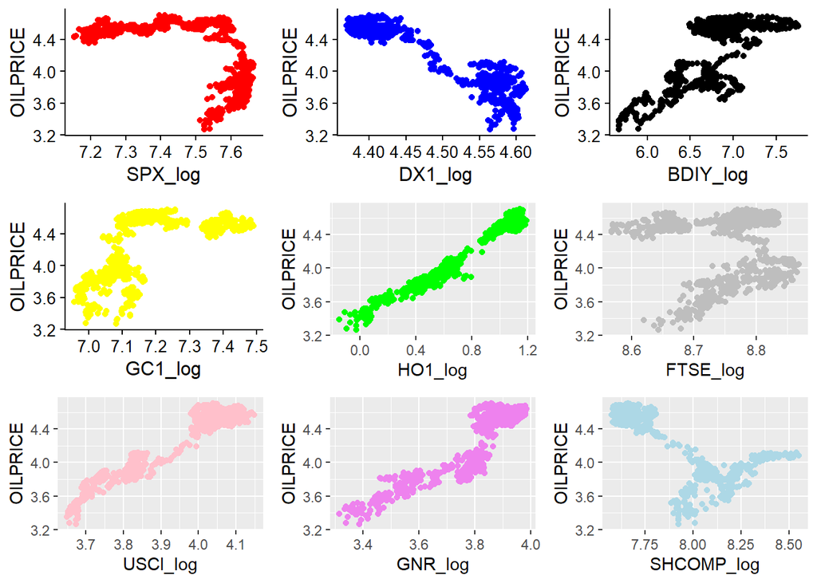

```r
#Show the plots
plot_grid(plot1,plot2,plot3,plot4,plot5,plot6,plot7,plot8,plot9)
```

Note that we omitted respLag in the plot for obvious reasons. It is the same variable but with lag values. The variables USCI_log, GNR_log and H01_log seem to have linear relationship with the target variable but we shall examine their significance further with the gamlss model.

Correlation Plots

Next, let us have an overview of the variable correlations with the target. First, examine a correlation plot of the entire data.

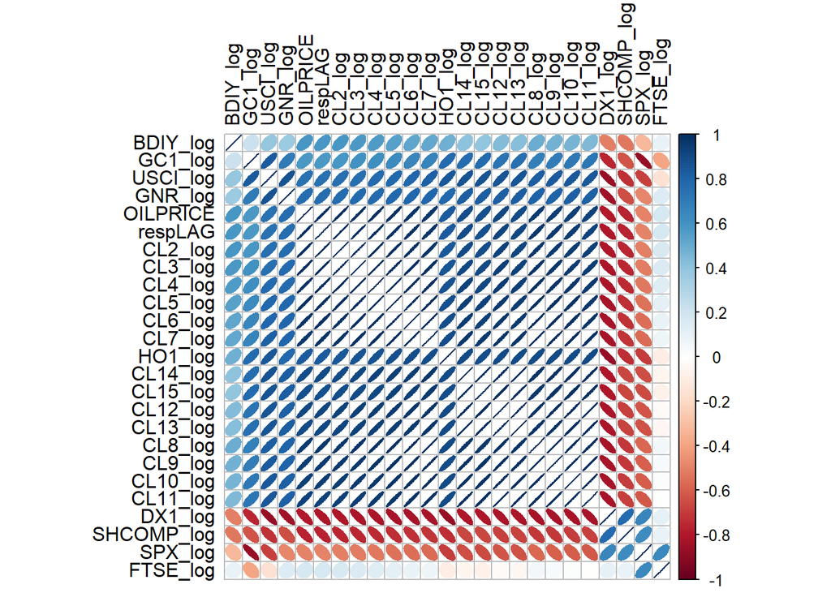

```r
oildata=oildata[,-26]
corr_mat=cor(oildata, method="s")
corrplot(corr_mat, method = "ellipse",
         order = "hclust",
         #addCoef.col = "black",
         tl.col = "black")
```

Then examine the correlation plot of the reduced data

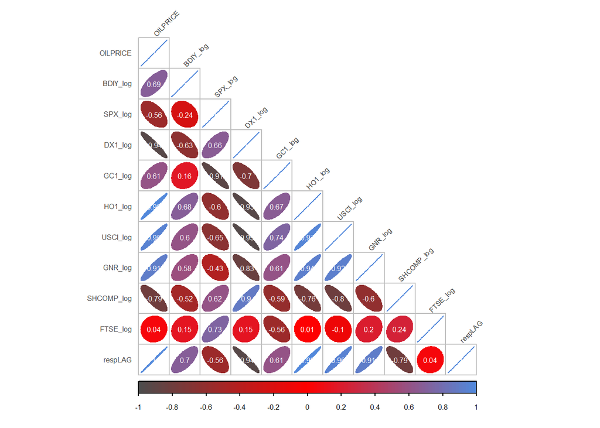

```r
cormat <- cor(oildata_s)

corrplot(cormat, method = "ellipse",
         type = "lower",
         tl.col = "#424242",
         tl.srt = 45,
         addCoef.col = "#ffffff",
         col = colorRampPalette(c("#4D4D4D", "red", "#5288DB"))(100),
         tl.cex = 0.5,
         number.cex = 0.5,
         number.font = 1,
         cl.cex = 0.5)
```

In all correlations, the following variables seem to be highly correlated with OILPRICE- USCI_log, HO1_log, SHOMP_log and DX1_log but we shall investigate further #their contributions to the model.

### 4. Model Building

The GAMLSS is a highly flexible statistical learning model. It is a unified framework for regression type of models. It is suitable for both univariate and multivariate forecasting. It allows any distribution for the target variable, and also models all the parameters of the distribution of the response variable Y. It enables a variety of penalized additive terms in the model for the distribution parameters. It can also deal with overdispersion, skewness and kurtosis.

#### Target Variable

Examine the distribution of the response variable before modeling. One of the most important modelling decisions for a GAMLSS model is the choice of the distribution for the response variable.

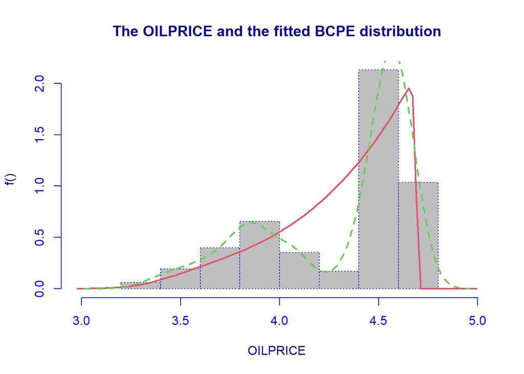

```
##
## Family:  c("BCPE", "Box-Cox Power Exponential")
## Fitting method: "nlminb"
##
## Call:  gamlssML(formula = OILPRICE, family = "BCPE")
##
## Mu Coefficients:
## [1]  4.374
## Sigma Coefficients:
## [1]  -2.877
## Nu Coefficients:
## [1]  9.382
## Tau Coefficients:
## [1]  3.339
##
##  Degrees of Freedom for the fit: 4 Residual Deg. of Freedom   996
## Global Deviance:     65.6076
##             AIC:     73.6076
##             SBC:     93.2387
```

```r
histDist(OILPRICE, family=BCPE,density=T)
```

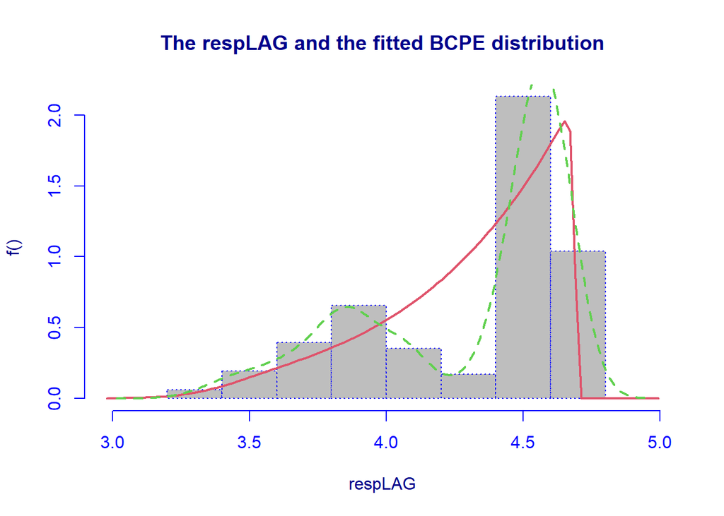

```
##
## Family:  c("BCPE", "Box-Cox Power Exponential")
## Fitting method: "nlminb"
##
## Call:  gamlssML(formula = respLAG, family = "BCPE")
##
## Mu Coefficients:
## [1]  4.375
## Sigma Coefficients:
## [1]  -2.88
## Nu Coefficients:
## [1]  9.423
## Tau Coefficients:
## [1]  3.334
##
##  Degrees of Freedom for the fit: 4 Residual Deg. of Freedom   996
## Global Deviance:     61.2959
##             AIC:     69.2959
##             SBC:     88.9269
```

```r
histDist(respLAG, family=BCPE,density=T)
```

#### Feature selection with the Boruta Algorithm

This is necessary to determine if any of the features are redundant. The Boruta algorithm is known as one of the best algorithms for feature selection.

```r
library(Boruta)
borC = Boruta(OILPRICE ~., data = oildata, doTrace = 2, maxRuns=50)
```

[output not shown]

[output not shown]

[output not shown]

[output not shown]

[output not shown]

[output not shown]

[output not shown]

[output not shown]

[output not shown]

[output not shown]

[output not shown]

[output not shown]

```
## After 12 iterations, +24 secs:
```

```
##  confirmed 19 attributes: CL10_log, CL11_log, CL12_log, CL13_log, CL14_log and 14 more;
```

```
##  still have 5 attributes left.
```

[output not shown]

[output not shown]

[output not shown]

[output not shown]

```
## After 16 iterations, +32 secs:
```

```
##  confirmed 1 attribute: SHCOMP_log;
```

```
##  still have 4 attributes left.
```

[output not shown]

[output not shown]

[output not shown]

```
## After 19 iterations, +38 secs:
```

```
##  confirmed 1 attribute: GC1_log;
```

```
##  still have 3 attributes left.
```

[output not shown]

[output not shown]

[output not shown]

[output not shown]

[output not shown]

[output not shown]

[output not shown]

[output not shown]

[output not shown]

[output not shown]

[output not shown]

[output not shown]

[output not shown]

[output not shown]

[output not shown]

[output not shown]

[output not shown]

[output not shown]

[output not shown]

[output not shown]

[output not shown]

[output not shown]

[output not shown]

[output not shown]

[output not shown]

[output not shown]

[output not shown]

[output not shown]

[output not shown]

[output not shown]

```r
print(borC)
```

```
## Boruta performed 49 iterations in 1.625229 mins.
##  21 attributes confirmed important: CL10_log, CL11_log, CL12_log,
## CL13_log, CL14_log and 16 more;
##  No attributes deemed unimportant.
##  3 tentative attributes left: BDIY_log, DX1_log, GNR_log;
```

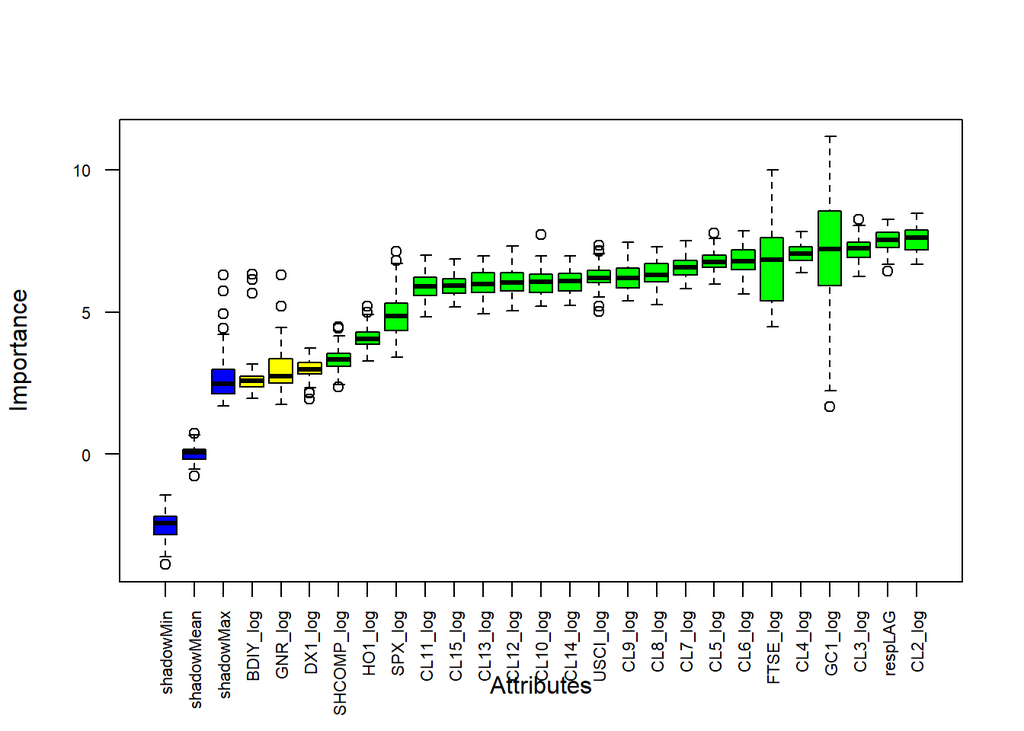

```r
par(pty='m')
plot(borC,las=2,cex.axis=0.7)
```

```r
#plotImpHistory(borC)
bor1=TentativeRoughFix(borC)
attStats(bor1)
```

```
##             meanImp medianImp   minImp    maxImp  normHits  decision
## CL2_log    7.578943  7.626442 6.684770  8.460582 1.0000000 Confirmed
## CL3_log    7.200186  7.231940 6.236072  8.251389 1.0000000 Confirmed
## CL4_log    7.070850  7.051380 6.368755  7.833642 1.0000000 Confirmed
## CL5_log    6.820805  6.767328 5.979346  7.777529 1.0000000 Confirmed
## CL6_log    6.828531  6.794303 5.633673  7.854206 1.0000000 Confirmed
## CL7_log    6.582238  6.569097 5.813503  7.512264 0.9795918 Confirmed
## CL8_log    6.363810  6.307045 5.258410  7.292151 0.9795918 Confirmed
## CL9_log    6.218554  6.201149 5.384297  7.461917 0.9795918 Confirmed
## CL10_log   6.070427  6.056412 5.203580  7.712388 0.9795918 Confirmed
## CL11_log   5.908999  5.894950 4.833423  7.002440 0.9591837 Confirmed
## CL12_log   6.104443  6.038538 5.039186  7.324655 1.0000000 Confirmed
## CL13_log   5.979022  5.985390 4.935904  6.975579 0.9591837 Confirmed
## CL14_log   6.076052  6.085933 5.228972  6.973927 0.9795918 Confirmed
## CL15_log   5.964185  5.918270 5.188372  6.865166 0.9795918 Confirmed
## BDIY_log   2.752309  2.571138 1.954571  6.315385 0.5306122 Confirmed
## SPX_log    4.981173  4.850059 3.420209  7.120903 0.9591837 Confirmed
## DX1_log    2.967687  2.975717 1.937079  3.726320 0.6938776 Confirmed
## GC1_log    7.066058  7.210262 1.655860 11.164172 0.8979592 Confirmed
## HO1_log    4.085747  4.043673 3.268228  5.205634 0.8979592 Confirmed
## USCI_log   6.237144  6.199327 5.005834  7.336415 0.9795918 Confirmed
## GNR_log    3.029656  2.751848 1.738646  6.300147 0.6122449 Confirmed
## SHCOMP_log 3.333937  3.327131 2.364755  4.491855 0.7959184 Confirmed
## FTSE_log   6.638928  6.845143 4.493184 10.005021 1.0000000 Confirmed
## respLAG    7.505236  7.530132 6.422416  8.262919 1.0000000 Confirmed
```

The Boruta algorithm confirms that all the variables are important for prediction of oil price. However, the three tentative attributes suggested will be investigated for significance in the gamlss model.

Hence, we decide to keep all the features but divide the data into two:

- 1. The entire dataframe (base_data) herein referred to as oildata
- 2. The sub_data(excluding CL2-CL15) herein referred to as oildata_s

#### Data Partition

To train our models, we partition the two datasets above in the 70/30 divide as follows:

- 1. Partition the base (full) data

```r
ind=sample(2, nrow(oildata),replace=T, prob=c(0.70,0.30))
train1=oildata[ind==1,]
test1= oildata[ind==2,]
dim(train1)
```

```
## [1] 699  25
```

```r
dim(test1)
```

```
## [1] 301  25
```

Partition the sub-data (reduced data)

```r
ind=sample(2, nrow(oildata_s),replace=T,prob=c(0.70,0.30))
train2=oildata_s[ind==1,]
test2= oildata_s[ind==2,]
dim(train2)
```

```
## [1] 709  11
```

```r
dim(test2)
```

```
## [1] 291  11
```

Model building

I shall build the following six models:

- 1. GAMLSS Model with no additive terms including all the variables(base_data)
- 2. GAMLSS Model with no additive terms excluding the CL2-CL15 variables (sub_data)
- 3. GAMLSS Model with additive terms including all the variables (base_data)
- 4. GAMLSS Model with additive terms excluding the CL2-CL15 variables (sub_data)
- 5. GAMLSS Model with no additive terms including selected significant variables
- 6. GAMLSS Model with additive terms including selected variables.

Let us proceed on model building as follows:

#### Model 1: GAMLSS Model with no additive terms including all the variables(base_data)

```r
model1 <- gamlss(OILPRICE ~ ., data = train1,
               trace = FALSE, family = BCPE)
shapiro.test(model1$residuals)
```

```
##
##  Shapiro-Wilk normality test
##
## data:  model1$residuals
## W = 0.99742, p-value = 0.346
```

```r
summary(model1)
```

```
## Family:  c("BCPE", "Box-Cox Power Exponential")
##
## Call:  gamlss(formula = OILPRICE ~ ., family = BCPE, data = train1,
##     trace = FALSE)
##
## Fitting method: RS()
##
## ------------------------------------------------------------------
## Mu link function:  identity
## Mu Coefficients:
##              Estimate Std. Error t value Pr(>|t|)
## (Intercept)  0.585370   0.132307   4.424 1.13e-05 ***
## CL2_log     -1.620765   0.199354  -8.130 2.06e-15 ***
## CL3_log      5.068313   0.490497  10.333  < 2e-16 ***
## CL4_log     -6.861920   0.384609 -17.841  < 2e-16 ***
## CL5_log      7.335365   0.485734  15.102  < 2e-16 ***
## CL6_log     -6.258020   1.104333  -5.667 2.16e-08 ***
## CL7_log     -1.656396   1.104501  -1.500   0.1342
## CL8_log      8.973141   0.977333   9.181  < 2e-16 ***
## CL9_log     -5.053077   0.568412  -8.890  < 2e-16 ***
## CL10_log    -0.153314   0.007268 -21.096  < 2e-16 ***
## CL11_log    -0.307865   0.505564  -0.609   0.5428
## CL12_log     0.047038   0.814242   0.058   0.9539
## CL13_log     2.135617   0.845297   2.526   0.0117 *
## CL14_log    -3.189746   0.775983  -4.111 4.43e-05 ***
## CL15_log     1.596888   0.375663   4.251 2.43e-05 ***
## BDIY_log    -0.005093   0.001122  -4.539 6.68e-06 ***
## SPX_log     -0.076021   0.007476 -10.169  < 2e-16 ***
## DX1_log     -0.079761   0.017282  -4.615 4.70e-06 ***
## GC1_log     -0.060488   0.006954  -8.698  < 2e-16 ***
## HO1_log     -0.021097   0.005045  -4.182 3.28e-05 ***
## USCI_log     0.071804   0.010769   6.668 5.42e-11 ***
## GNR_log      0.007102   0.008804   0.807   0.4202
## SHCOMP_log  -0.005949   0.002752  -2.162   0.0310 *
## FTSE_log     0.069130   0.009852   7.017 5.55e-12 ***
## respLAG      0.933806   0.028180  33.138  < 2e-16 ***
## ---
## Signif. codes:  0 '***' 0.001 '**' 0.01 '*' 0.05 '.' 0.1 ' ' 1
##
## ------------------------------------------------------------------
```

[output cut: 15 more lines]

```
## Tau Coefficients:
##             Estimate Std. Error t value Pr(>|t|)
## (Intercept) -0.42485    0.05115  -8.307 5.12e-16 ***
## ---
## Signif. codes:  0 '***' 0.001 '**' 0.01 '*' 0.05 '.' 0.1 ' ' 1
##
## ------------------------------------------------------------------
## No. of observations in the fit:  699
## Degrees of Freedom for the fit:  28
##       Residual Deg. of Freedom:  671
##                       at cycle:  20
##
## Global Deviance:     -3502.239
##             AIC:     -3446.239
##             SBC:     -3318.849
```

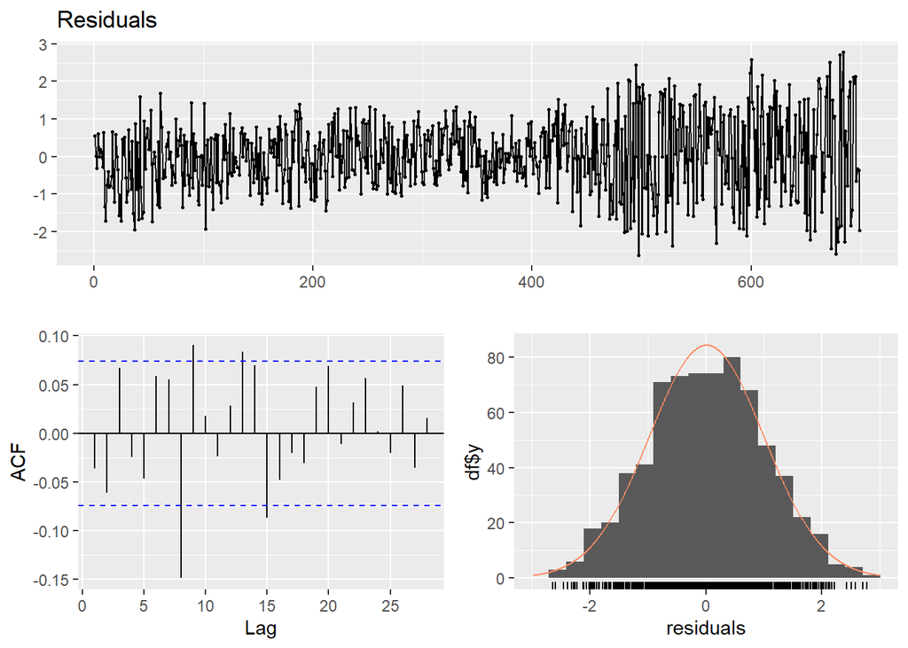

```r
checkresiduals(model1$residuals)
```

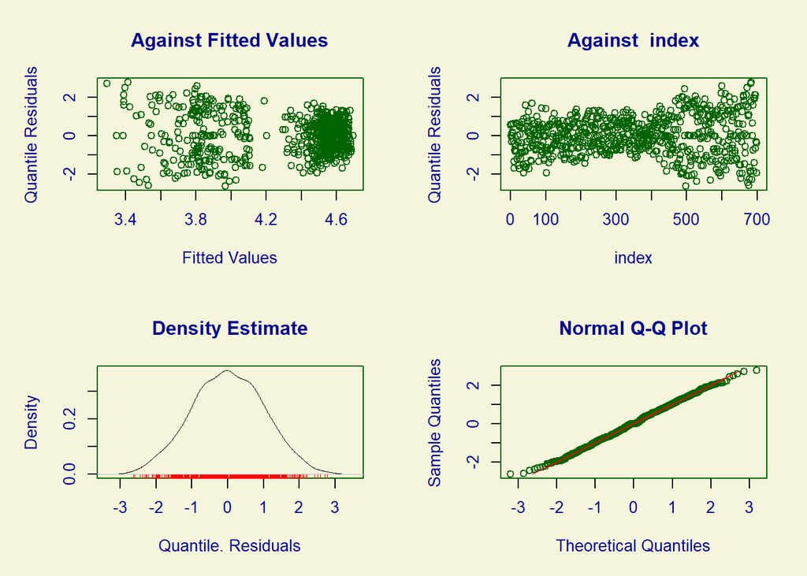

```
##        Summary of the Quantile Residuals
##                            mean   =  0.008883182
##                        variance   =  0.9931419
##                coef. of skewness  =  -0.003437321
##                coef. of kurtosis  =  2.664449
## Filliben correlation coefficient  =  0.9989369
```

```r
plot(model1)
```

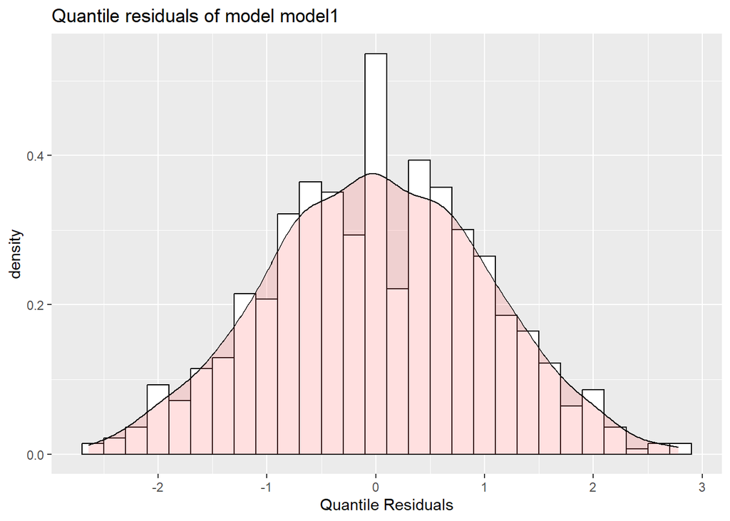

```r
resid_density(model1)
```

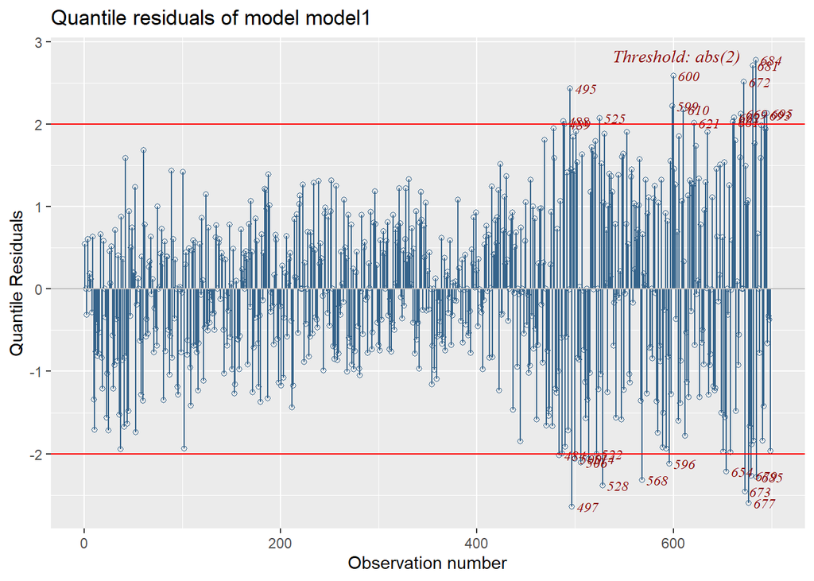

```r
resid_index(model1)
```

```r
df.residual(model1)
```

```
## [1] 671
```

#### Model 2: GAMLSS Model with no additive terms excluding the CL2-CL15 variables (sub_data)

```r
model2 <- gamlss(OILPRICE ~ ., data = train2,
               trace = FALSE, family = BCPE)
shapiro.test(model2$residuals)
```

```
##
##  Shapiro-Wilk normality test
##
## data:  model2$residuals
## W = 0.99817, p-value = 0.6624
```

```r
summary(model2)
```

```
## Family:  c("BCPE", "Box-Cox Power Exponential")
##
## Call:  gamlss(formula = OILPRICE ~ ., family = BCPE, data = train2,
##     trace = FALSE)
##
## Fitting method: RS()
##
## ------------------------------------------------------------------
## Mu link function:  identity
## Mu Coefficients:
##              Estimate Std. Error t value Pr(>|t|)
## (Intercept)  0.944197   0.001455 649.037  < 2e-16 ***
## BDIY_log    -0.007107   0.002042  -3.481 0.000531 ***
## SPX_log     -0.069864   0.001889 -36.989  < 2e-16 ***
## DX1_log     -0.094684   0.001313 -72.084  < 2e-16 ***
## GC1_log     -0.060640   0.003122 -19.422  < 2e-16 ***
## HO1_log      0.002325   0.001573   1.478 0.139833
## USCI_log     0.032304   0.003657   8.833  < 2e-16 ***
## GNR_log      0.006791   0.003325   2.042 0.041505 *
## SHCOMP_log   0.005784   0.001456   3.974 7.82e-05 ***
## FTSE_log     0.044408   0.000694  63.985  < 2e-16 ***
## respLAG      0.975290   0.001332 731.947  < 2e-16 ***
## ---
## Signif. codes:  0 '***' 0.001 '**' 0.01 '*' 0.05 '.' 0.1 ' ' 1
##
## ------------------------------------------------------------------
## Sigma link function:  log
## Sigma Coefficients:
##             Estimate Std. Error t value Pr(>|t|)
## (Intercept) -5.19130    0.05297     -98   <2e-16 ***
## ---
## Signif. codes:  0 '***' 0.001 '**' 0.01 '*' 0.05 '.' 0.1 ' ' 1
##
## ------------------------------------------------------------------
## Nu link function:  identity
## Nu Coefficients:
##             Estimate Std. Error t value Pr(>|t|)
## (Intercept)  -13.816      7.979  -1.732   0.0838 .
## ---
## Signif. codes:  0 '***' 0.001 '**' 0.01 '*' 0.05 '.' 0.1 ' ' 1
##
## ------------------------------------------------------------------
## Tau link function:  log
## Tau Coefficients:
##             Estimate Std. Error t value Pr(>|t|)
## (Intercept)  -0.3003     0.0668  -4.496 8.11e-06 ***
## ---
## Signif. codes:  0 '***' 0.001 '**' 0.01 '*' 0.05 '.' 0.1 ' ' 1
##
## ------------------------------------------------------------------
## No. of observations in the fit:  709
## Degrees of Freedom for the fit:  14
##       Residual Deg. of Freedom:  695
##                       at cycle:  20
##
## Global Deviance:     -3530.256
##             AIC:     -3502.256
##             SBC:     -3438.362
```

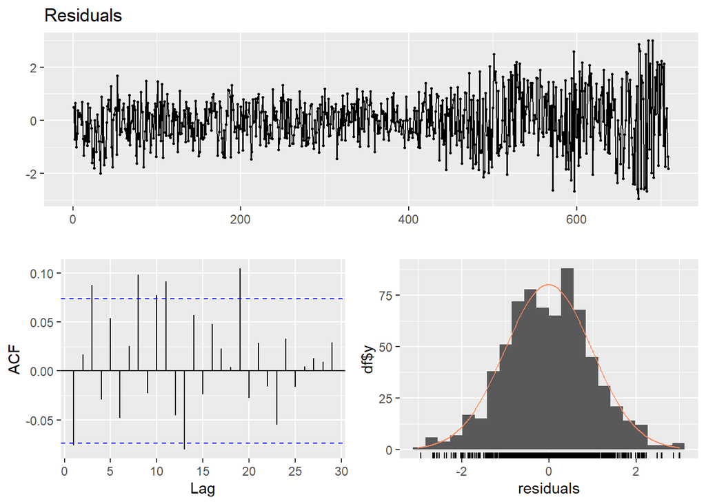

```r
checkresiduals(model2$residuals)
```

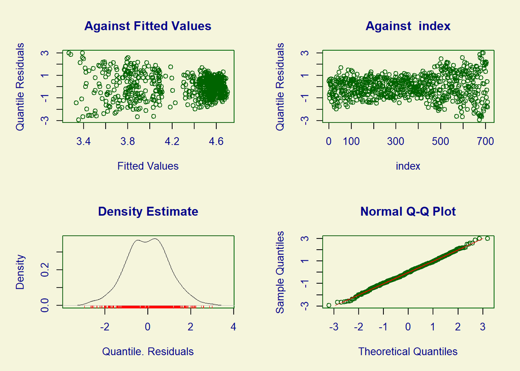

```
##        Summary of the Quantile Residuals
##                            mean   =  -0.009999695
##                        variance   =  0.9996805
##                coef. of skewness  =  0.009103242
##                coef. of kurtosis  =  3.025826
## Filliben correlation coefficient  =  0.9992364
```

```r
plot(model2)
```

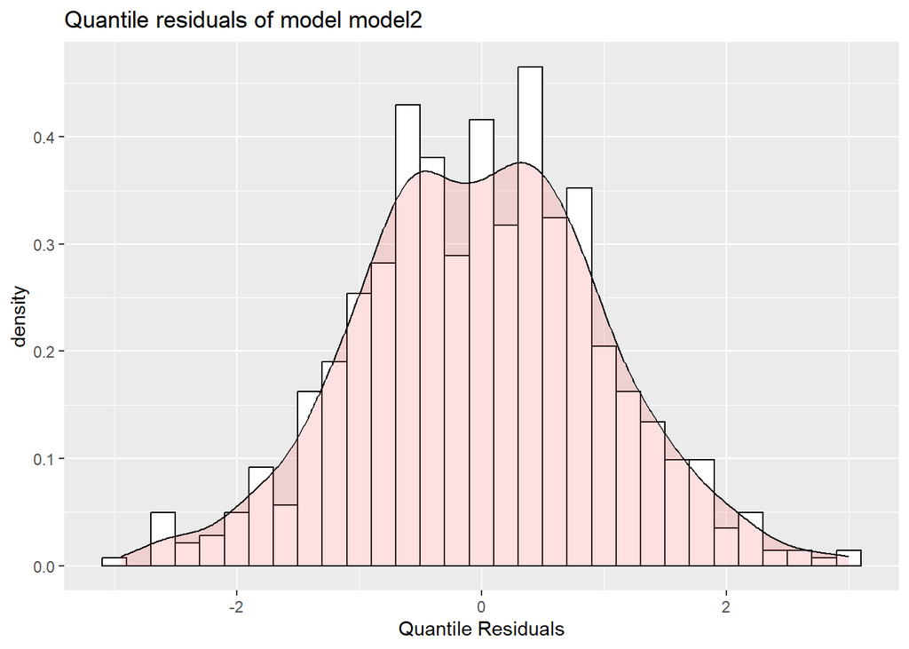

```r
resid_density(model2)
```

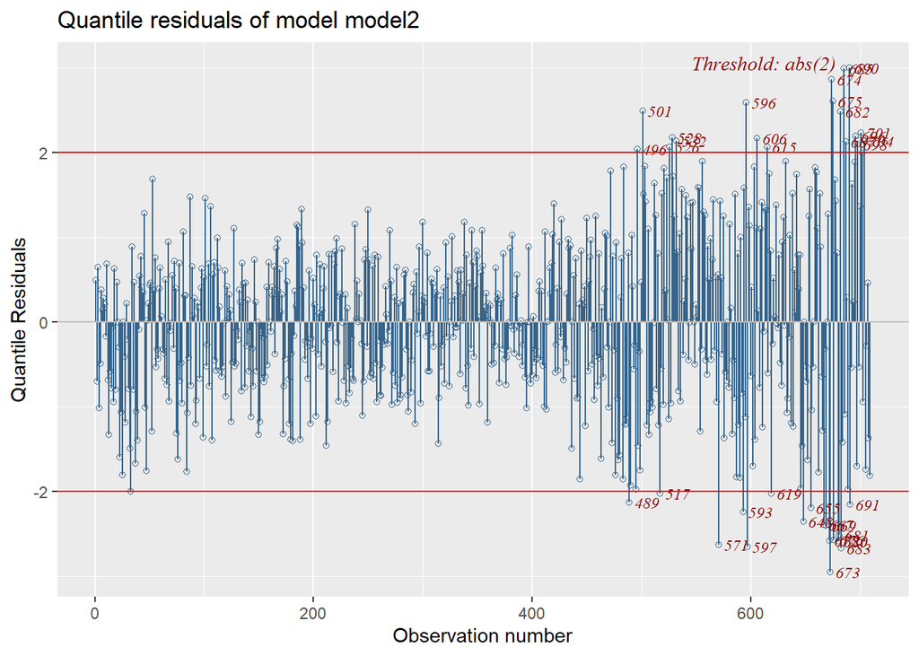

```r
resid_index(model2)
```

```r
df.residual(model2)
```

```
## [1] 695
```

#### Model with Additive Smoothing Terms

The GAMLSS model allows the user to model the distribution parameters mu, sigma, nu and tau as linear, non-linear parametric, non-parametric (smooth) function of the explanatory variables and/or random effects terms. For fitting non-linear, non-parametric (smooth) functions or random effects terms an additive term function has to be fitted. After switching between all the other functions, the best penalized smoothing function with the best non parametric results applied to this model were the pvc splines.

#### Model 3: GAMLSS Model with additive terms including all the variables (base_data)

```r
model3 <-
  gamlss(
    OILPRICE~ pvc(respLAG) + pvc(BDIY_log) + pvc(SPX_log) + pvc(DX1_log) + pvc(GC1_log)
               + pvc(HO1_log) + pvc(USCI_log) + pvc(GNR_log) + pvc(SHCOMP_log) + pvc(FTSE_log) + pvc(CL2_log)
    + pvc(CL3_log) + pvc(CL4_log) + pvc(CL5_log) + pvc(CL6_log) + pvc(CL7_log) + pvc(CL8_log) + pvc(CL9_log)
    + pvc(CL10_log) + pvc(CL11_log) + pvc(CL12_log) + pvc(CL13_log) + pvc(CL14_log) + pvc(CL15_log),
    family = BCPE,
    data = train1)
```

```
## GAMLSS-RS iteration 1: Global Deviance = -2360.27
## GAMLSS-RS iteration 2: Global Deviance = -3086.264
## GAMLSS-RS iteration 3: Global Deviance = -3444.486
## GAMLSS-RS iteration 4: Global Deviance = -3523.944
## GAMLSS-RS iteration 5: Global Deviance = -3536.056
## GAMLSS-RS iteration 6: Global Deviance = -3537.345
## GAMLSS-RS iteration 7: Global Deviance = -3540.835
## GAMLSS-RS iteration 8: Global Deviance = -3542.992
## GAMLSS-RS iteration 9: Global Deviance = -3544.582
## GAMLSS-RS iteration 10: Global Deviance = -3545.106
## GAMLSS-RS iteration 11: Global Deviance = -3546.911
## GAMLSS-RS iteration 12: Global Deviance = -3549.787
## GAMLSS-RS iteration 13: Global Deviance = -3550.858
## GAMLSS-RS iteration 14: Global Deviance = -3550.431
## GAMLSS-RS iteration 15: Global Deviance = -3550.925
## GAMLSS-RS iteration 16: Global Deviance = -3551.948
## GAMLSS-RS iteration 17: Global Deviance = -3553.098
## GAMLSS-RS iteration 18: Global Deviance = -3551.327
## GAMLSS-RS iteration 19: Global Deviance = -3552.569
## GAMLSS-RS iteration 20: Global Deviance = -3553.733
```

```r
summary(model3)
```

```
## Family:  c("BCPE", "Box-Cox Power Exponential")
##
## Call:
## gamlss(formula = OILPRICE ~ pvc(respLAG) + pvc(BDIY_log) + pvc(SPX_log) +
##     pvc(DX1_log) + pvc(GC1_log) + pvc(HO1_log) + pvc(USCI_log) +
##     pvc(GNR_log) + pvc(SHCOMP_log) + pvc(FTSE_log) + pvc(CL2_log) +
##     pvc(CL3_log) + pvc(CL4_log) + pvc(CL5_log) + pvc(CL6_log) +
##     pvc(CL7_log) + pvc(CL8_log) + pvc(CL9_log) + pvc(CL10_log) +
##     pvc(CL11_log) + pvc(CL12_log) + pvc(CL13_log) + pvc(CL14_log) +
##     pvc(CL15_log), family = BCPE, data = train1)
##
## Fitting method: RS()
##
## ------------------------------------------------------------------
## Mu link function:  identity
## Mu Coefficients:
##                   Estimate Std. Error  t value Pr(>|t|)
## (Intercept)      0.7887934  0.0291040   27.103  < 2e-16 ***
## pvc(respLAG)     0.8515384  0.0082012  103.831  < 2e-16 ***
## pvc(BDIY_log)   -0.0046071  0.0001909  -24.135  < 2e-16 ***
## pvc(SPX_log)    -0.0978966  0.0018218  -53.737  < 2e-16 ***
## pvc(DX1_log)    -0.1116495  0.0031404  -35.553  < 2e-16 ***
## pvc(GC1_log)    -0.0814159  0.0015935  -51.092  < 2e-16 ***
## pvc(HO1_log)     0.0006618  0.0007448    0.889  0.37473
## pvc(USCI_log)    0.0969982  0.0018262   53.115  < 2e-16 ***
## pvc(GNR_log)     0.0055001  0.0018994    2.896  0.00396 **
## pvc(SHCOMP_log) -0.0066228  0.0004947  -13.387  < 2e-16 ***
## pvc(FTSE_log)    0.1050129  0.0019952   52.632  < 2e-16 ***
## pvc(CL2_log)    -1.2240133  0.0542841  -22.548  < 2e-16 ***
## pvc(CL3_log)     3.7726621  0.1238134   30.471  < 2e-16 ***
## pvc(CL4_log)    -4.0173818  0.0898939  -44.690  < 2e-16 ***
## pvc(CL5_log)     4.6577820  0.0937348   49.691  < 2e-16 ***
## pvc(CL6_log)    -6.7263740  0.2101167  -32.013  < 2e-16 ***
## pvc(CL7_log)     2.4546488  0.1707396   14.377  < 2e-16 ***
## pvc(CL8_log)     2.9814696  0.1679774   17.749  < 2e-16 ***
## pvc(CL9_log)    -1.7495910  0.1212057  -14.435  < 2e-16 ***
## pvc(CL10_log)   -0.1324320  0.0011734 -112.863  < 2e-16 ***
## pvc(CL11_log)    0.4878012  0.1199831    4.066 5.61e-05 ***
## pvc(CL12_log)   -0.1882781  0.1537011   -1.225  0.22120
## pvc(CL13_log)   -1.5841409  0.1554930  -10.188  < 2e-16 ***
```

[output cut: 25 more lines]

```
## Signif. codes:  0 '***' 0.001 '**' 0.01 '*' 0.05 '.' 0.1 ' ' 1
##
## ------------------------------------------------------------------
## NOTE: Additive smoothing terms exist in the formulas:
##  i) Std. Error for smoothers are for the linear effect only.
## ii) Std. Error for the linear terms may not be reliable.
## ------------------------------------------------------------------
## No. of observations in the fit:  699
## Degrees of Freedom for the fit:  230.9851
##       Residual Deg. of Freedom:  468.0149
##                       at cycle:  20
##
## Global Deviance:     -3553.733
##             AIC:     -3091.762
##             SBC:     -2040.861
```

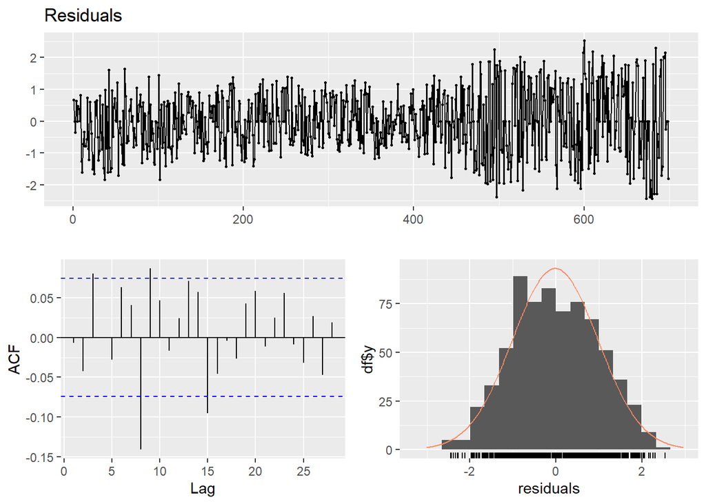

```r
checkresiduals(model3$residuals)
```

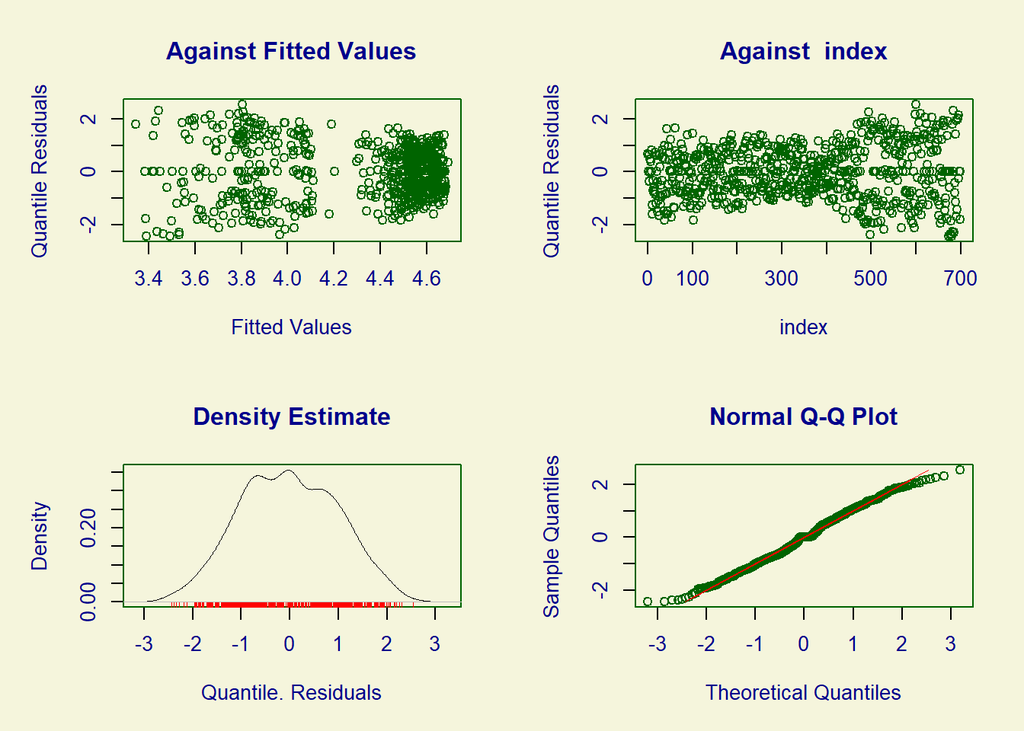

```
##        Summary of the Quantile Residuals
##                            mean   =  -0.02099566
##                        variance   =  0.9893686
##                coef. of skewness  =  0.02206215
##                coef. of kurtosis  =  2.389099
## Filliben correlation coefficient  =  0.9962151
```

```r
plot(model3)
```

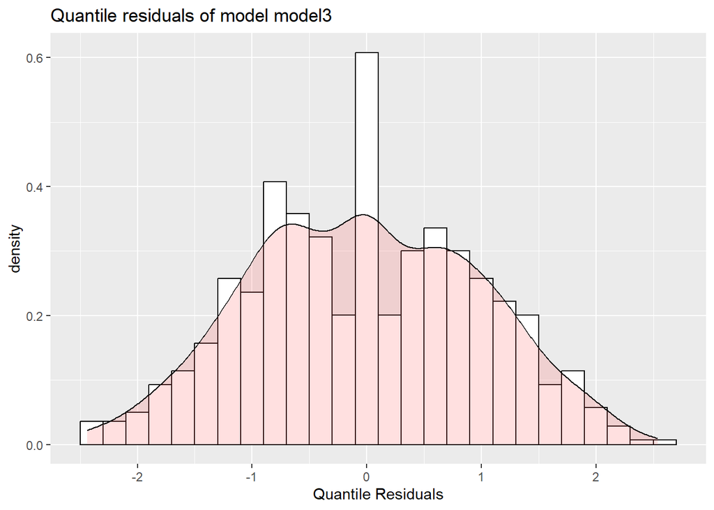

```r
resid_density(model3)
```

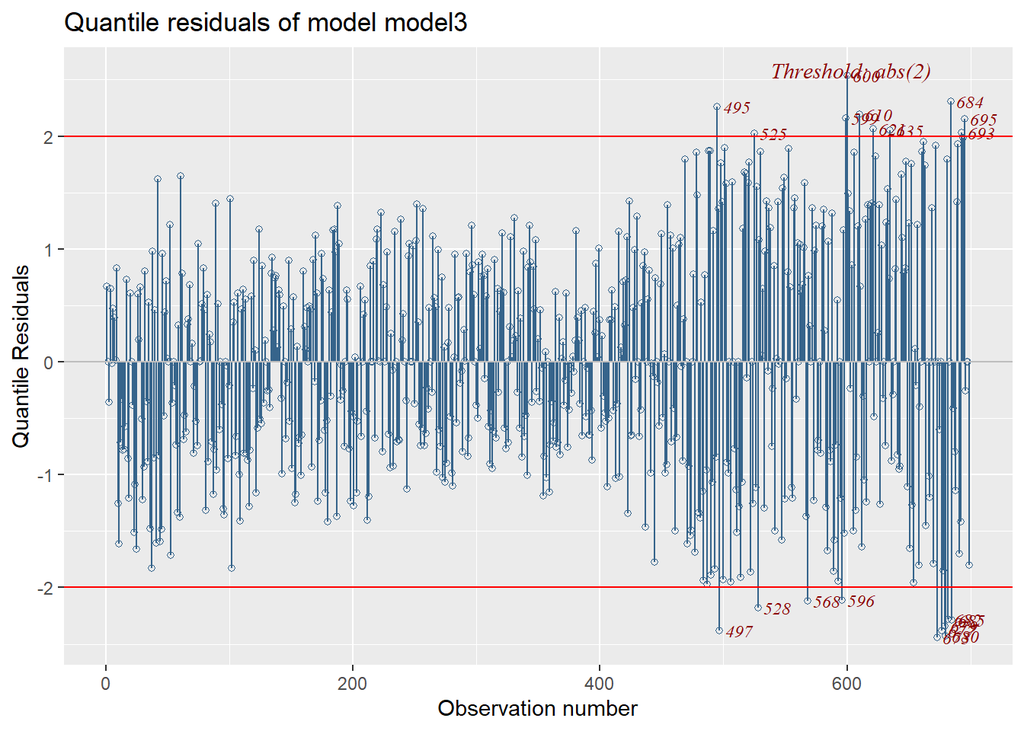

```r
resid_index(model3)
```

```r
df.residual(model3)
```

```
## [1] 468.0149
```

```r
# 0 > DF PARAMETER RANGE =< 6.
#find.hyper(model3,parameters=c(0.01,6))
#find.hyper(model4,parameters=c(0.01,6))
```

#### Model4: GAMLSS Model with additive terms excluding the CL2-CL15 variables (sub_data)

```r
model4<-
  gamlss(formula = OILPRICE ~ pvc(respLAG) + pvc(BDIY_log) +
    pvc(SPX_log) + pvc(DX1_log) + pvc(GC1_log) + pvc(HO1_log) +  pvc(USCI_log) + pvc(GNR_log) + pvc(SHCOMP_log) + pvc(FTSE_log),
    family = BCPE, data = train2)
```

```
## GAMLSS-RS iteration 1: Global Deviance = -2402.188
## GAMLSS-RS iteration 2: Global Deviance = -3188.727
## GAMLSS-RS iteration 3: Global Deviance = -3551.986
## GAMLSS-RS iteration 4: Global Deviance = -3588.118
## GAMLSS-RS iteration 5: Global Deviance = -3585.406
## GAMLSS-RS iteration 6: Global Deviance = -3597.233
## GAMLSS-RS iteration 7: Global Deviance = -3603.843
## GAMLSS-RS iteration 8: Global Deviance = -3606.065
## GAMLSS-RS iteration 9: Global Deviance = -3604.924
## GAMLSS-RS iteration 10: Global Deviance = -3605.544
## GAMLSS-RS iteration 11: Global Deviance = -3607.424
## GAMLSS-RS iteration 12: Global Deviance = -3605.887
## GAMLSS-RS iteration 13: Global Deviance = -3605.506
## GAMLSS-RS iteration 14: Global Deviance = -3606.493
## GAMLSS-RS iteration 15: Global Deviance = -3608.782
## GAMLSS-RS iteration 16: Global Deviance = -3606.821
## GAMLSS-RS iteration 17: Global Deviance = -3607.631
## GAMLSS-RS iteration 18: Global Deviance = -3609.261
## GAMLSS-RS iteration 19: Global Deviance = -3612.95
## GAMLSS-RS iteration 20: Global Deviance = -3613.14
```

```r
summary(model4)
```

```
## Family:  c("BCPE", "Box-Cox Power Exponential")
##
## Call:
## gamlss(formula = OILPRICE ~ pvc(respLAG) + pvc(BDIY_log) + pvc(SPX_log) +
##     pvc(DX1_log) + pvc(GC1_log) + pvc(HO1_log) + pvc(USCI_log) +
##     pvc(GNR_log) + pvc(SHCOMP_log) + pvc(FTSE_log), family = BCPE,
##     data = train2)
##
## Fitting method: RS()
##
## ------------------------------------------------------------------
## Mu link function:  identity
## Mu Coefficients:
##                   Estimate Std. Error t value Pr(>|t|)
## (Intercept)      0.6153540  0.0411594  14.951  < 2e-16 ***
## pvc(respLAG)     0.9840470  0.0014985 656.700  < 2e-16 ***
## pvc(BDIY_log)   -0.0006354  0.0003152  -2.016   0.0443 *
## pvc(SPX_log)    -0.0567057  0.0021225 -26.716  < 2e-16 ***
## pvc(DX1_log)     0.0266838  0.0047924   5.568 3.81e-08 ***
## pvc(GC1_log)    -0.0343440  0.0023385 -14.686  < 2e-16 ***
## pvc(HO1_log)    -0.0259602  0.0019669 -13.198  < 2e-16 ***
## pvc(USCI_log)    0.0212138  0.0034519   6.145 1.41e-09 ***
## pvc(GNR_log)     0.0373616  0.0031861  11.726  < 2e-16 ***
## pvc(SHCOMP_log) -0.0239464  0.0010863 -22.043  < 2e-16 ***
## pvc(FTSE_log)   -0.0007299  0.0035628  -0.205   0.8378
## ---
## Signif. codes:  0 '***' 0.001 '**' 0.01 '*' 0.05 '.' 0.1 ' ' 1
##
## ------------------------------------------------------------------
## Sigma link function:  log
## Sigma Coefficients:
##             Estimate Std. Error t value Pr(>|t|)
## (Intercept) -5.12118    0.04892  -104.7   <2e-16 ***
## ---
## Signif. codes:  0 '***' 0.001 '**' 0.01 '*' 0.05 '.' 0.1 ' ' 1
##
## ------------------------------------------------------------------
## Nu link function:  identity
## Nu Coefficients:
##             Estimate Std. Error t value Pr(>|t|)
```

[output cut: 8 more lines]

```
## Signif. codes:  0 '***' 0.001 '**' 0.01 '*' 0.05 '.' 0.1 ' ' 1
##
## ------------------------------------------------------------------
## NOTE: Additive smoothing terms exist in the formulas:
##  i) Std. Error for smoothers are for the linear effect only.
## ii) Std. Error for the linear terms may not be reliable.
## ------------------------------------------------------------------
## No. of observations in the fit:  709
## Degrees of Freedom for the fit:  79.53303
##       Residual Deg. of Freedom:  629.467
##                       at cycle:  20
##
## Global Deviance:     -3613.14
##             AIC:     -3454.074
##             SBC:     -3091.096
```

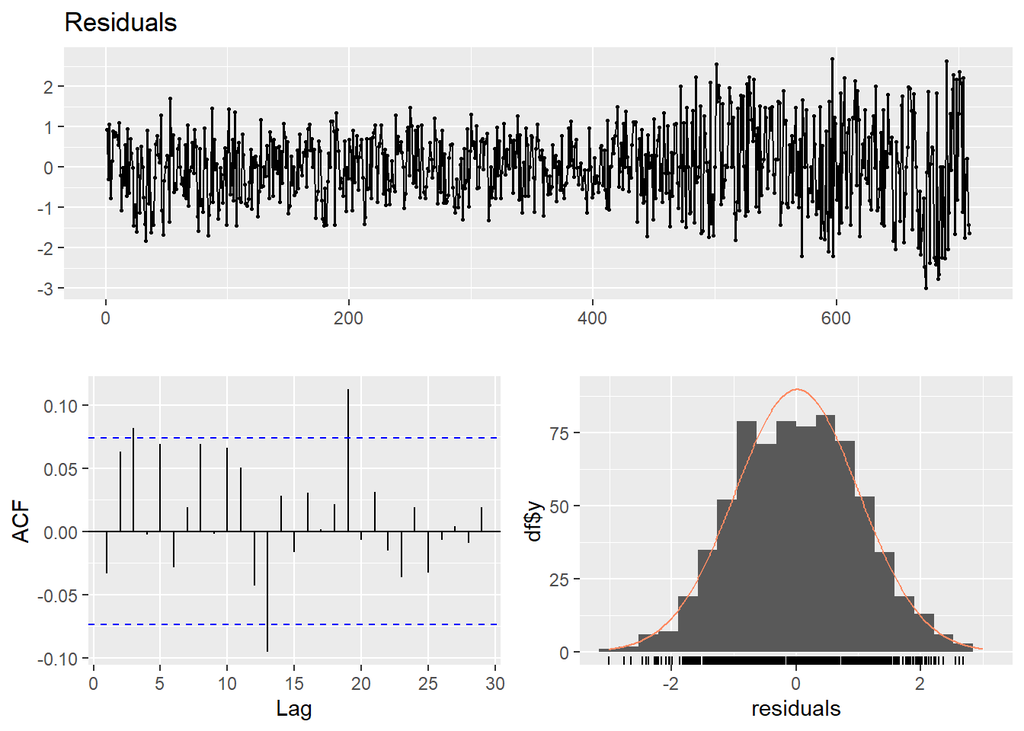

```r
checkresiduals(model4$residuals)
```

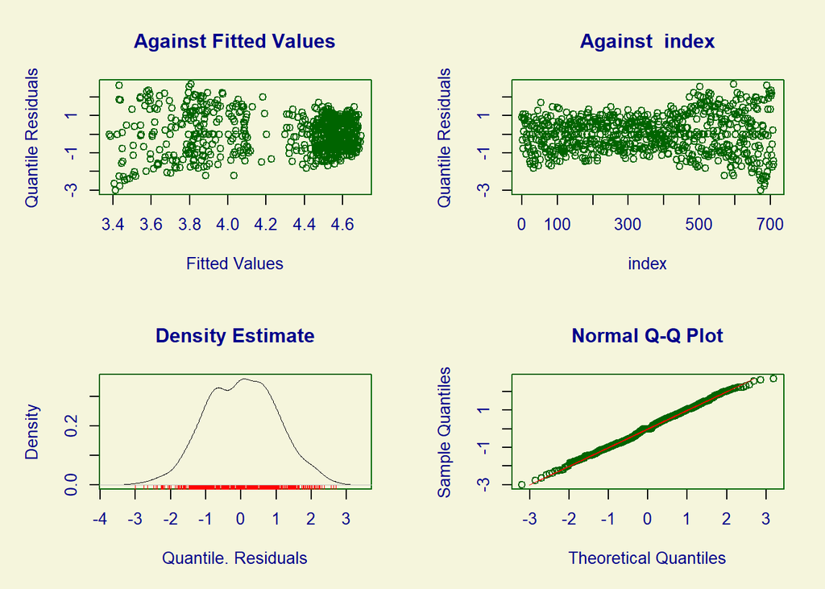

```
##        Summary of the Quantile Residuals
##                            mean   =  0.01242614
##                        variance   =  0.9956457
##                coef. of skewness  =  -0.003758624
##                coef. of kurtosis  =  2.691372
## Filliben correlation coefficient  =  0.9986125
```

```r
plot(model4)
```

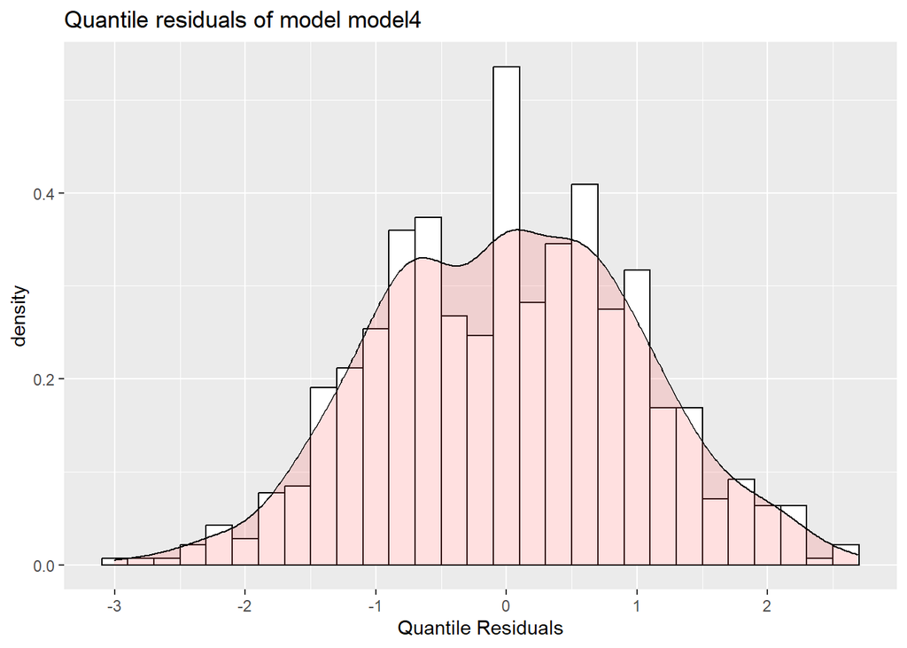

```r
resid_density(model4)
```

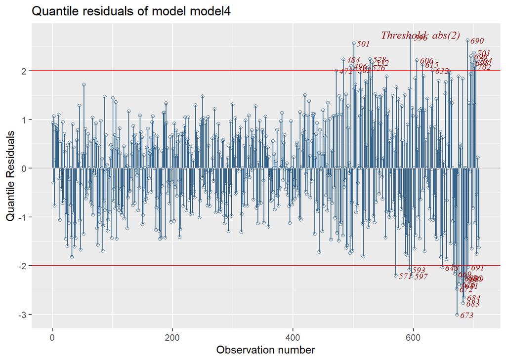

```r
resid_index(model4)
```

```r
df.residual(model4)
```

```
## [1] 629.467
```

#### Variable Selection

```r
# Stepwise model selection
#stepGAIC(model1,direction='both')
```

```r
#Random forest variable importance for the full model.
control <- trainControl(method="repeatedcv", number=10, repeats=3)
modelrf <- train(OILPRICE~., data=oildata_s, method="rf", trControl=control)
modelrf
```

```
## Random Forest
##
## 1000 samples
##   10 predictor
##
## No pre-processing
## Resampling: Cross-Validated (10 fold, repeated 3 times)
## Summary of sample sizes: 900, 900, 900, 900, 900, 900, ...
## Resampling results across tuning parameters:
##
##   mtry  RMSE        Rsquared   MAE
##    2    0.02267494  0.9963782  0.01570911
##    6    0.02277129  0.9963648  0.01567955
##   10    0.02321482  0.9962313  0.01610137
##
## RMSE was used to select the optimal model using the smallest value.
## The final value used for the model was mtry = 2.
```

```r
varImp(modelrf)
```

```
## rf variable importance
##
##            Overall
## USCI_log   100.000
## respLAG     89.569
## HO1_log     71.267
## DX1_log     62.286
## SHCOMP_log  57.000
## GNR_log     35.475
## GC1_log     19.254
## BDIY_log    14.874
## SPX_log      3.881
## FTSE_log     0.000
```

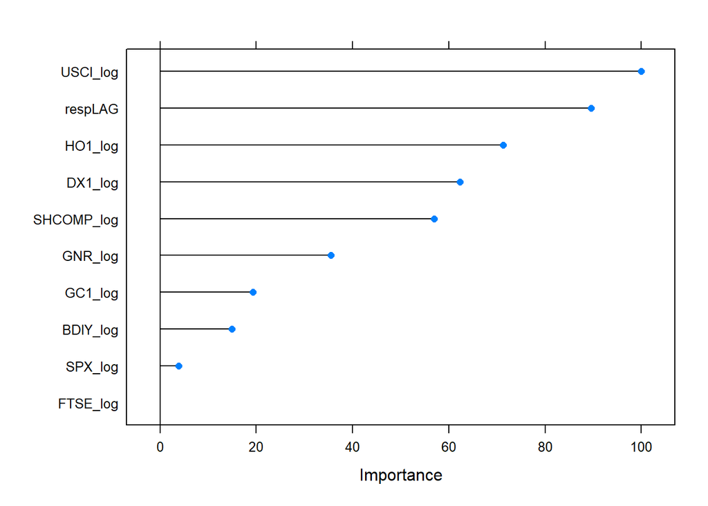

```r
plot(varImp(modelrf, scale=T))
```

#### Model 5: GAMLSS Model with no additive terms including selected variables.

```r
model5 <- gamlss(OILPRICE ~ USCI_log +
                       DX1_log +
                       HO1_log +
                       SHCOMP_log + respLAG,
              data = train2,
              trace = FALSE, family = BCPE)
shapiro.test(model5$residuals)
```

```
##
##  Shapiro-Wilk normality test
##
## data:  model5$residuals
## W = 0.99782, p-value = 0.4948
```

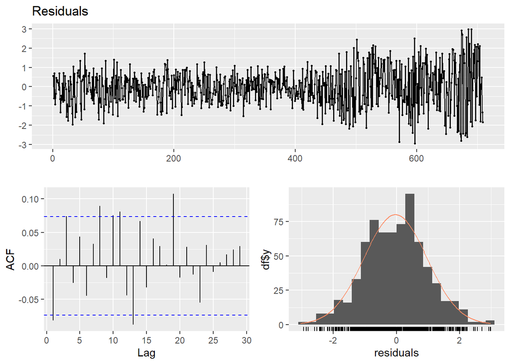

```r
checkresiduals(model5$residuals)
```

```r
summary(model5)
```

```
## Family:  c("BCPE", "Box-Cox Power Exponential")
##
## Call:
## gamlss(formula = OILPRICE ~ USCI_log + DX1_log + HO1_log + SHCOMP_log +
##     respLAG, family = BCPE, data = train2, trace = FALSE)
##
## Fitting method: RS()
##
## ------------------------------------------------------------------
## Mu link function:  identity
## Mu Coefficients:
##               Estimate Std. Error t value Pr(>|t|)
## (Intercept)  0.0753207  0.1451917   0.519   0.6041
## USCI_log    -0.0014502  0.0148235  -0.098   0.9221
## DX1_log      0.0005714  0.0269833   0.021   0.9831
## HO1_log      0.0199593  0.0088734   2.249   0.0248 *
## SHCOMP_log  -0.0048892  0.0042733  -1.144   0.2530
## respLAG      0.9879139  0.0069346 142.462   <2e-16 ***
## ---
## Signif. codes:  0 '***' 0.001 '**' 0.01 '*' 0.05 '.' 0.1 ' ' 1
##
## ------------------------------------------------------------------
## Sigma link function:  log
## Sigma Coefficients:
##             Estimate Std. Error t value Pr(>|t|)
## (Intercept) -5.21116    0.04209  -123.8   <2e-16 ***
## ---
## Signif. codes:  0 '***' 0.001 '**' 0.01 '*' 0.05 '.' 0.1 ' ' 1
##
## ------------------------------------------------------------------
## Nu link function:  identity
## Nu Coefficients:
##             Estimate Std. Error t value Pr(>|t|)
## (Intercept)  -21.622      7.479  -2.891  0.00396 **
## ---
## Signif. codes:  0 '***' 0.001 '**' 0.01 '*' 0.05 '.' 0.1 ' ' 1
##
## ------------------------------------------------------------------
## Tau link function:  log
## Tau Coefficients:
##             Estimate Std. Error t value Pr(>|t|)
## (Intercept) -0.22639    0.05638  -4.015 6.57e-05 ***
## ---
## Signif. codes:  0 '***' 0.001 '**' 0.01 '*' 0.05 '.' 0.1 ' ' 1
##
## ------------------------------------------------------------------
## No. of observations in the fit:  709
## Degrees of Freedom for the fit:  9
##       Residual Deg. of Freedom:  700
##                       at cycle:  20
##
## Global Deviance:     -3514.529
##             AIC:     -3496.529
##             SBC:     -3455.454
```

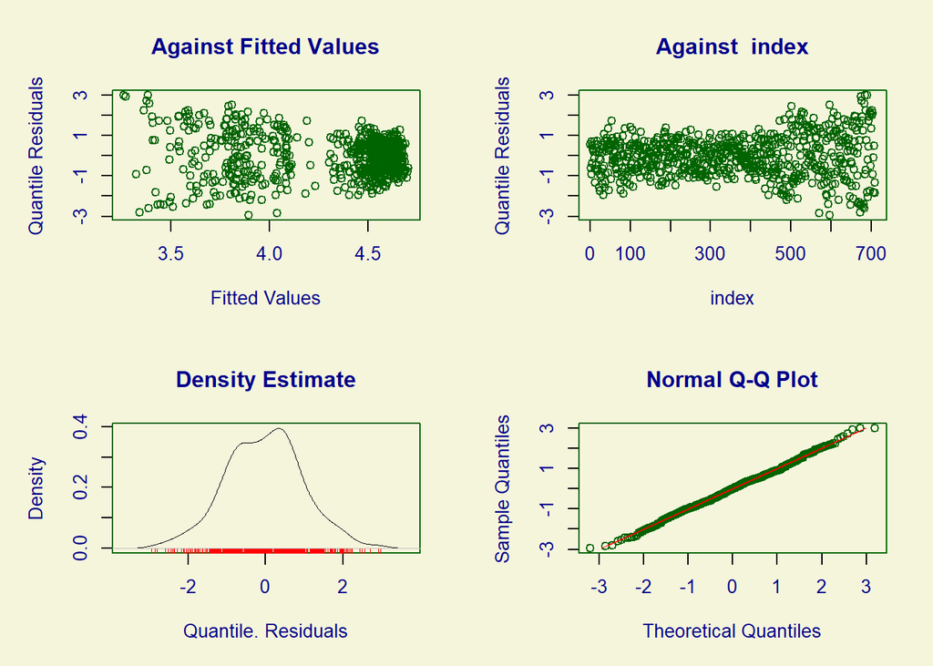

```
##        Summary of the Quantile Residuals
##                            mean   =  -0.03479735
##                        variance   =  0.9982953
##                coef. of skewness  =  0.02111461
##                coef. of kurtosis  =  3.066739
## Filliben correlation coefficient  =  0.9990633
```

```r
plot(model5)
```

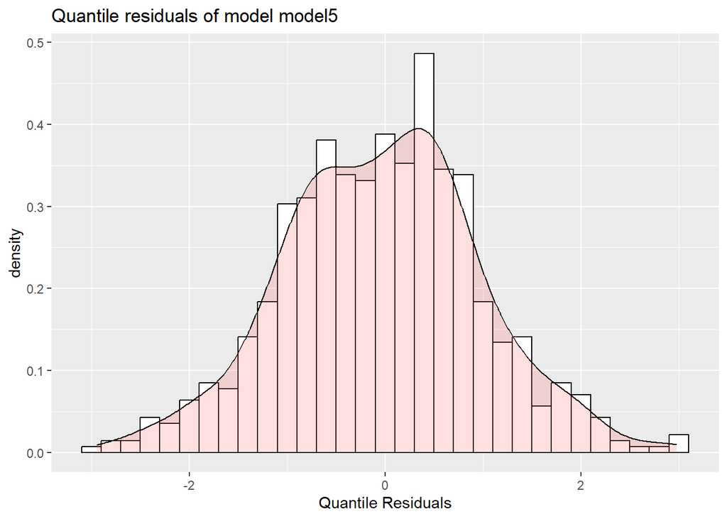

```r
resid_density(model5)
```

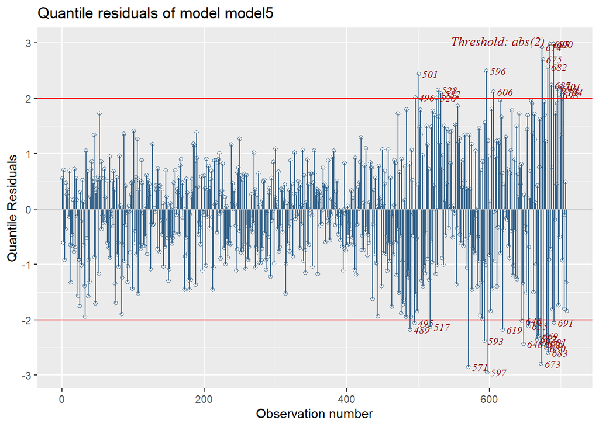

```r
resid_index(model5)
```

```r
df.residual(model5)
```

```
## [1] 700
```